# acta_editing_analysis_3_disease_w_gene_summary

Aaron Wagen

UCL

28 January 2024

```r
args <- list(
   detect_summary_comparison_sig_file = here::here("results",
                                                  "brain",
                                                  "jacusa_detect",
                                                  "detect_summary_comparison_sig_edits.RDS"),
   # detect_summary_folder = here::here("results",
   #                                     "brain",
   #                                     "jacusa_detect"),
    sample_annotation_file = here::here("raw_data",
                                        "acta_neuropath_bulk",
                                        "SampleAnnot_metadata.txt"),
    output_folder = here::here("results"),
  lengths_summary_path = here::here("references",
                                    "ensembl93_gene_lengths_summary.RDS"),
  reduced_gtf = here::here("references", "ensembl93_reduced_gtf.RDS")
)




plot_labels = c("Decreased_editing" = "Decreased editing",
                "Increased_editing" = "Increased editing",
                "Lost_edit_sites" = "Lost editing sites",
                "New_edit_sites" = "New editing sites",
                "astro_nt_vs_asyn" = "Astrocyte untreated vs a-syn",
                "neuron_nt_vs_asyn" = "Neuron untreated vs a-syn",
                "cocult_nt_vs_asyn" = "Coculture untreated vs a-syn",
                "astro_nt" = "Astrocyte untreated",
                "astro_asyn" = "Astrocyte a-syn",
                "cocult_nt" = "Coculture untreated",
                "cocult_asyn" = "Coculture a-syn",
                "neuron_nt" = "Neuron untreated",
                "neuron_asyn" = "Neuron a-syn",
                "exon" = "Exon",
                "intron" = "Intron",
                "intergenic" = "Intergenic",
                "not_significant" = "Not significant",
                "significant" = "Significant",
                "Astrocyte_increase" = "Astrocyte increase",
                "Astrocyte_decrease" = "Astrocyte decrease",
                "Neuron_increase" = "Neuron increase",
                "Neuron_decrease" = "Neuron decrease",
                "Coculture_increase" = "Coculture increase",
                "Coculture_decrease" = "Coculture decrease",
                "no_treatment" = "Baseline",
                "increase" = "Increase",
                "decrease" = "Decrease",
                "increased_sites" = "Increased editing rate",
                "decreased_sites" = "Decreased editing rate",
                "treated_edits" = "a-syn",
                "untreated_edits" = "Untreated",
                "exon" = "Exon",
                "intron" = "Intron",
                "intergenic" = "Intergenic",
                "increased" = "Increase",
                "decreased" = "Decreased"
                )

plot_labeller = as_labeller(plot_labels)



named_palette = c(
  increased_sites = "deeppink3",
  increased = "deeppink3",
  new_sites = "hotpink1",
  decreased_sites = "#2a75b2",
  decreased = "#2a75b2",
  lost_sites = "lightskyblue",
  astro_nt = "#7FDEEA",
  astro_asyn = "#0097A6",
  neuron_nt = "#FF91C8",
  neuron_asyn = "deeppink3",
  cocult_nt = "#9FA7D8",
  cocult_asyn = "#303F9F",
  Control = "#1d9064",
  no_treatment = "#1d9064",
  DLB = "#ce490a",
  PD  = "#625aa4",
  `1uM_syn_oligomer`= "#625aa4",
  PDD = "#de0077",
    exon = "#fc6a0f",
  intron = "#9db8e0",
  intergenic = "#1a62a5"
)
```

## 0.1 Background data re samples

Sample annotation and information

```r
# Load gene lengths
gene_lengths <- readRDS(args$lengths_summary_path)

editing_metrics <- c("Edits", "edit_adjusted")
outcome_to_explore = "Disease_Group"
covariates_used = c("RIN", "Sex")
```

```r
# Load annotation file
metadata <- read_delim(args$sample_annotation_file)
metadata <- metadata %>%
   dplyr::select(Sample = sample_name, Disease_Group, Sex, AoO, AoD, DD, PMI, RIN = RINe_bulkRNA_Tapestation, aSN, TAU, AB = `thal AB`, aCG_aSN_score = `aCG aSN score`) %>%
  dplyr::mutate(sample_id = Sample)
```

Samples per disease group

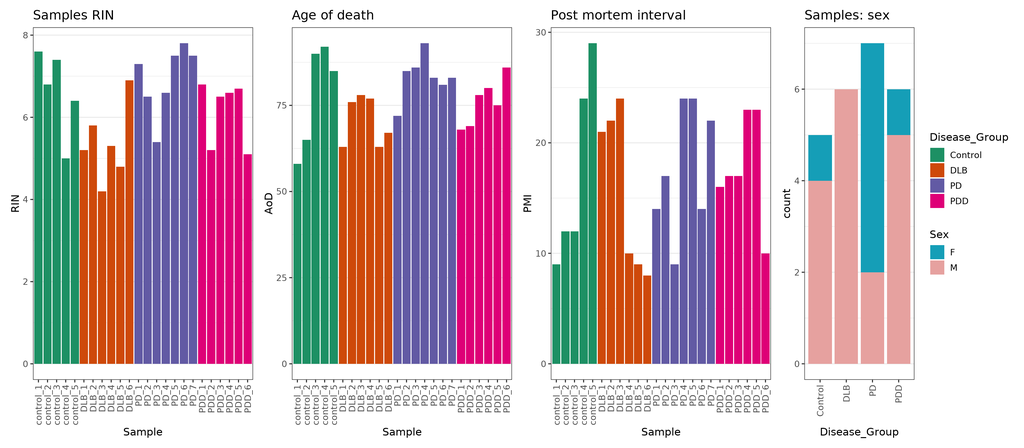

```r
RIN_bar <- metadata %>%
  ggplot(aes(x=Sample, y = RIN, fill = Disease_Group)) +
  geom_bar(stat = "identity") +
  theme_aw +
    scale_fill_manual(values = named_palette) +
  labs(title = "Samples RIN")


AOD_bar <- metadata %>%
  ggplot(aes(x=Sample, y = AoD, fill = Disease_Group)) +
  geom_bar(stat = "identity") +
  theme_aw +
      scale_fill_manual(values = named_palette) +
  labs(title = "Age of death")

PMI_bar <- metadata %>%
  ggplot(aes(x=Sample, y = PMI, fill = Disease_Group)) +
  geom_bar(stat = "identity") +
  theme_aw +
      scale_fill_manual(values = named_palette) +
  labs(title = "Post mortem interval")

sex_bar <- metadata %>%
  ggplot(aes(x=Disease_Group, fill = Sex)) +
  geom_bar(stat = "count",
           position = "stack") +
  theme_aw +
      scale_fill_paletteer_d("werpals::pan",
                        direction = -1) +
  labs(title = "Samples: sex")



(RIN_bar | AOD_bar | PMI_bar | sex_bar | plot_layout(guides = "collect", widths = c(2,2,2,1)))
```

```r
# Load file of significant results
# master_df <- readRDS(args$detect_summary_comparison_sig_file)
# master_df$Disease_Group <- factor(master_df$Disease_Group)
```

# 1 Load edit site files

```r
# Load file of significant results
master_df <- readRDS(args$detect_summary_comparison_sig_file)
# Replace NA gene types with intergenic (in efficient manner)
master_df$gene_type[is.na(master_df$gene_type)] <- "intergenic"
master_df$Disease_Group <- factor(master_df$Disease_Group)
```

```r
contrasts = list(PD = c("Control", "PD"),
                 DLB = c("Control", "DLB"),
                 PDD = c("Control", "PDD"))
region_to_explore <- NULL
```

# 2 Results

```r
for (contrast_number in 1:length(contrasts)) {

    contrast_to_explore <- contrasts[[contrast_number]]
    # Generate Markdown header

if (is.null(region_to_explore)){
  cat("##", contrast_to_explore[1], " vs. ", contrast_to_explore[[2]], "\n\n")
} else if (!is.null(region_to_explore)){
  cat("##", region_to_explore, ":",  contrast_to_explore[1], " vs. ", contrast_to_explore[[2]], "\n\n")
}

   # Analysis and plotting code for the current region and contrast
    contrast_list <- list(Control = contrast_to_explore[1],
                          Disease = contrast_to_explore[2])
    disease = contrast_to_explore[2]

    print(str_c("Exploring ", region_to_explore, ": ", contrast_to_explore[1], " vs. ", contrast_to_explore[[2]]))

    comparison_df <- master_df %>%
        dplyr::filter(Disease_Group %in% contrast_to_explore)

    # Write output table
    summary_edits_df <- comparison_df %>%
        dplyr::select(seqnames, start, end, strand, Sample, Edits, z.score)
    write_delim(summary_edits_df,
               file = str_c(args$output_folder, "/brain/sig_edits_", contrast_to_explore[1], "_", contrast_to_explore[2], ".tsv"))

    # Replace NAs in genic type with intergenic, and create column of collapsed biotypes for plotting
   comparison_df <- comparison_df %>%
      dplyr::filter(Edits < 1) %>%  #Filter to editing rate < 1.
      dplyr::mutate(biotype_plots = as_factor(gene_biotype)) %>%
      remove_suffix_from_gene_id(., column = "gene_id")

    # Recode and reorder biotype levels for plotting
    levels(comparison_df$biotype_plots) <- vep_levels_BIOTYPE

    # Factorise locus
    comparison_df$locus <- factor(comparison_df$locus)

    # Factorise disease group, checking levels in data match levels in factor to be
         comparison_df$Disease_Group <- factor(comparison_df$Disease_Group)
    dataframe_levels <- levels(comparison_df$Disease_Group)
    if (!all(dataframe_levels %in% contrast_to_explore) && all(contrast_to_explore %in% dataframe_levels)) {
      errorCondition("Supplied sorting factor does not match levels in data")
    }
    levels(comparison_df$Disease_Group) <- contrast_to_explore

    # Find sample counts and consequences for annotation later
    sample_counts <- comparison_df %>%
        ungroup() %>%
      distinct(Sample, Disease_Group) %>%
      count(Disease_Group)

    loci_consequences <- comparison_df %>%
      dplyr::select(locus, gene_name, biotype_plots, gene_type) %>%
      dplyr::distinct(locus, .keep_all = T)

    # Filter by number of sites common within groups and between samples
    sites_to_explore <- data.table::copy(comparison_df)
    number_common_samples_per_group = 2
    site_label <- "common_2_sample"
    site_annotation <- "Sites common to 2 samples per group: "

    common_loci <- find_sites_loci_common_to_x_samples(sites_df = sites_to_explore,
                                                       sample_counts_df = sample_counts,
                                                       no_common_samples_per_site = number_common_samples_per_group )

    sites_subset <- filter_sites_by_locus_vector(sites_df = sites_to_explore,
                                                 vector_of_loci = common_loci,
                                                 factor_list = contrast_list)


      # Baseline plots: rate and site number
    # edit_mean_rate_box <- create_box_plot_editing_metric_per_disease_group(edit_summary_df = sites_subset,
    #                                                                        plotting_variable = "Edits") +
    #   scale_y_continuous(trans = "identity") +
    #   labs(subtitle = "Editing rate per sample")

    edit_mean_rate_histogram <- plot_residual_histogram(regression_df = sites_subset,
                                                        resid_column = "Edits",
                                                        fill_variable = "Disease_Group") +
      labs(subtitle = "Raw editing rate (w/out rate = 1)",
           x = "Editing rate")


    total_sites <- plot_site_number_boxplot(sites_subset)

    number_sites_per_sample <- sites_subset %>%
      count(Sample) %>%
      dplyr::rename(n_sites_per_sample = n)

    sites_subset <- sites_subset %>%
      left_join(number_sites_per_sample,
                by = "Sample")


    ###  Regression by sites ####
    lm_results_sites <- regress_editing(sites_df = sites_subset,
                                        editing_metric = "Edits",
                                        covariates = covariates_used,
                                        factor_list = contrast_list,
                                        outcome_measure = outcome_to_explore,
                                        disease = disease)


    site_residual_histogram <- plot_residual_histogram(regression_df = lm_results_sites$sites_subset_residuals,
                                                                resid_column = '.resid',
                                                                fill_variable = 'Disease_Group') +
      labs(subtitle = "Site residuals, no outcome")


    mean_residual_histogram <-  plot_residual_histogram(regression_df = lm_results_sites$mean_residuals_df %>%
                                                          dplyr::mutate(Disease_Group = fct_recode(Disease_Group, !!disease := "Disease")),
                                                                resid_column = 'mean_residuals_per_feature',
                                                                fill_variable = 'Disease_Group') +
      labs(subtitle = "Mean residuals per feature, no outcome")


    sites_residual_histogram_with_outcome <-  plot_residual_histogram(regression_df = lm_results_sites$sites_subset_residuals_with_outcome,
                                                                resid_column = '.resid',
                                                                fill_variable = 'Disease_Group') +
      labs(subtitle = "Site residuals, with outcome")



    forest_plot_sites <- create_forest_plot_from_lm(linear_model = lm_results_sites$lm_results_with_outcome,
                                                    disease = disease) +
      labs(title = "Regression of sites")
```

```r
    ## Compare baseline to change  for plotting
    compare_baseline_df <- compare_proportions_baseline_altered(lm_results_list = lm_results_sites,
                                                                loci_consequences = loci_consequences,
                                                                factor_list = contrast_list)
    genic_dif_plot <- plot_compare_proportions_baseline(compare_proportions_df = compare_baseline_df,
                                                        metric_to_plot = "gene_type",
                                                        fill_label = "Genic Location")
    biotype_dif_plot <- plot_compare_proportions_baseline(compare_proportions_df = compare_baseline_df,
                                                          metric_to_plot = "biotype_plots",
                                                          fill_label = "Biotype")

    ### Create gene editing summary metric
    gene_metric_df <- sites_subset %>%
      get_editing_summary_metric(summary_df = .,
                                 gene_lengths_df = gene_lengths,
                                 outcome_measure = outcome_to_explore,
                                 covariates = covariates_used,
                                 factor_list = contrast_list) %>%
      left_join(.,
                number_sites_per_sample,
                by = "Sample")

    # Plot number of sites per gene
    no_sites_boxplot <- create_box_plot_editing_metric_per_disease_group(edit_summary_df = gene_metric_df,
                                                                         plotting_variable = "no_sites") +
      scale_y_continuous(trans = "identity") +
      labs(subtitle = "No sites per gene", x = NULL)

    # Define metrics and labels in a named list
    editing_metrics <- list(
      mean_adjusted = "Mean edits per gene",
      no_sites_adjusted = "No. of sites per gene",
      mean_over_exon_length_adjusted = "Mean over exon length",
      mean_x_no_sites_adjusted = "Mean * No. of sites",
      complete_mean_adjusted = "Complete editing metric",
      complete_mean_genelength_adjusted = "Complete metric / gene length"
    )


    # Use lapply to iterate over each metric and return a list of plots of various parts of the gene metric
    forest_plots <- lapply(names(editing_metrics), function(edit_variable_to_plot) {

      edit_variable_label <- editing_metrics[[edit_variable_to_plot]]

      lm_results <- regress_editing(
        sites_df = gene_metric_df,
        editing_metric = edit_variable_to_plot,
        covariates = covariates_used,
        factor_list = contrast_list,
        outcome_measure = outcome_to_explore,
        disease = disease
      )

      forest_plot <- create_forest_plot_from_lm(linear_model = lm_results$lm_results_with_outcome,
                                                disease = disease) +
        labs(title = edit_variable_label)

      return(forest_plot)
    })

    # Name the list elements according to the editing metric names
    names(forest_plots) <- names(editing_metrics)
    title_forest <- title_plot("Regressions")

    all_forest_plots <- c(list(title_forest, forest_plot_sites = forest_plot_sites), forest_plots[names(editing_metrics)])




    ### Run regression with covariates and metrics all scaled, and n_site_per_gene log transformed
    sites_subset_scaled <- sites_subset %>%
      dplyr::mutate(RIN = scale(RIN))

    lm_results_sites_scaled <- regress_editing(sites_df = sites_subset_scaled,
                                               editing_metric = "Edits",
                                               covariates = c("n_sites_per_sample", covariates_used),
                                               factor_list = contrast_list,
                                               outcome_measure = outcome_to_explore,
                                               disease = disease)

    forest_plot_sites_scaled <- create_forest_plot_from_lm(linear_model = lm_results_sites_scaled$lm_results_with_outcome,
                                                           disease = disease) +
      labs(title = "Regression of sites - scaled")

    gene_metric_df_scaled <- sites_subset_scaled %>%
      get_editing_summary_metric_scaled(summary_df = .,
                                 gene_lengths_df = gene_lengths,
                                 outcome_measure = outcome_to_explore,
                                 covariates = covariates_used,
                                 factor_list = contrast_list) %>%
      left_join(.,
                number_sites_per_sample,
                by = "Sample")


    # Use lapply to iterate over each metric and return a list of plots of various parts of the gene metric
    forest_plots_scaled <- lapply(names(editing_metrics), function(edit_variable_to_plot) {

      edit_variable_label <- editing_metrics[[edit_variable_to_plot]]

      lm_results_scaled <- regress_editing(
        sites_df = gene_metric_df_scaled,
        editing_metric = edit_variable_to_plot,
        covariates = c("n_sites_per_sample", covariates_used),
        factor_list = contrast_list,
        outcome_measure = outcome_to_explore,
        disease = disease
      )

      forest_plot_scaled <- create_forest_plot_from_lm(linear_model = lm_results_scaled$lm_results_with_outcome,
                                                       disease = disease) +
        labs(title = edit_variable_label)

      return(forest_plot_scaled)
    })

    # Name the list elements according to the editing metric names
    names(forest_plots_scaled) <- names(editing_metrics)
    title_scaled <- title_plot("Scale site covariates \n and log10 nsites per gene")

    all_forest_plots_scaled <- c(list(title_scaled, forest_plot_sites = forest_plot_sites_scaled), forest_plots_scaled[names(editing_metrics)])





    ### Run regression covaried by n sites per sample
    # Regression by number of sites + n_sites_per_sample
    lm_results_sites_nsites <- regress_editing(sites_df = sites_subset,
                                               editing_metric = "Edits",
                                               covariates = c("n_sites_per_sample", covariates_used),
                                               factor_list = contrast_list,
                                               outcome_measure = outcome_to_explore,
                                               disease = disease)
```

```r
    forest_plot_sites_nsites <- create_forest_plot_from_lm(linear_model = lm_results_sites_nsites$lm_results_with_outcome,
                                                           disease = disease) +
      labs(title = "Regression of sites w site_no")


     gene_metric_df <- sites_subset %>%
      get_editing_summary_metric(summary_df = .,
                                 gene_lengths_df = gene_lengths,
                                 outcome_measure = outcome_to_explore,
                                 covariates = covariates_used,
                                 factor_list = contrast_list) %>%
      left_join(.,
                number_sites_per_sample,
                by = "Sample")

    # Use lapply to iterate over each metric and return a list of plots of various parts of the gene metric
    forest_plots_nsites <- lapply(names(editing_metrics), function(edit_variable_to_plot) {

      edit_variable_label <- editing_metrics[[edit_variable_to_plot]]

      lm_results_nsites <- regress_editing(
        sites_df = gene_metric_df,
        editing_metric = edit_variable_to_plot,
        covariates = c("n_sites_per_sample", covariates_used),
        factor_list = contrast_list,
        outcome_measure = outcome_to_explore,
        disease = disease
      )

      forest_plot_nsites <- create_forest_plot_from_lm(linear_model = lm_results_nsites$lm_results_with_outcome,
                                                       disease = disease) +
        labs(title = edit_variable_label)

      return(forest_plot_nsites)
    })

    # Name the list elements according to the editing metric names
    names(forest_plots_nsites) <- names(editing_metrics)
    title_nsites <- title_plot("Regressions covaried \n for nsites per sample")

    all_forest_plots_nsites <- c(list(title_nsites, forest_plot_sites = forest_plot_sites_nsites), forest_plots_nsites[names(editing_metrics)])





    ### Create summary plot
    cat("\n")
    print(summary_plot <- (edit_mean_rate_histogram | total_sites | no_sites_boxplot |sites_residual_histogram_with_outcome | site_residual_histogram | mean_residual_histogram |  genic_dif_plot ) /
            (Reduce(`|`, all_forest_plots)) +
            (Reduce(`|`, all_forest_plots_scaled)) +
            (Reduce(`|`, all_forest_plots_nsites)) +
            plot_layout(guides = "collect") +
            plot_annotation(title = paste0(region_to_explore, " : ", disease, " verse control")))

    if (is.null(region_to_explore)){
      ggsave(summary_plot,
             file = here::here(str_c("figures/rm_full_edits_",
                               disease, ".png")),
             device = "png",
             units = "cm",
             height = 44,
             width = 60)
    } else if (!is.null(region_to_explore)){
      ggsave(summary_plot,
             file = here::here(str_c("figures/rm_full_edits_",
                               region_to_explore, "_", disease, ".png")),
             device = "png",
             units = "cm",
             height = 44,
             width = 62)
    }




    cat("\n\n")

}
```

## 2.1 Control vs. PD

[1] “Exploring : Control vs. PD” [1] “Control group; 5 samples” [1] “PD group; 7 samples” [1] “Grouping gene summary by:” [1] “Sample” “gene_id” “Disease_Group” “RIN”  
[5] “Sex”  
[1] “0 out of 9617 genes do not have a gene length.” [1] “Grouping gene summary by:” [1] “Sample” “gene_id” “Disease_Group” “RIN”  
[5] “Sex”  
[1] “0 out of 9617 genes do not have a gene length.” [1] “Grouping gene summary by:” [1] “Sample” “gene_id” “Disease_Group” “RIN”  
[5] “Sex”  
[1] “0 out of 9617 genes do not have a gene length.”

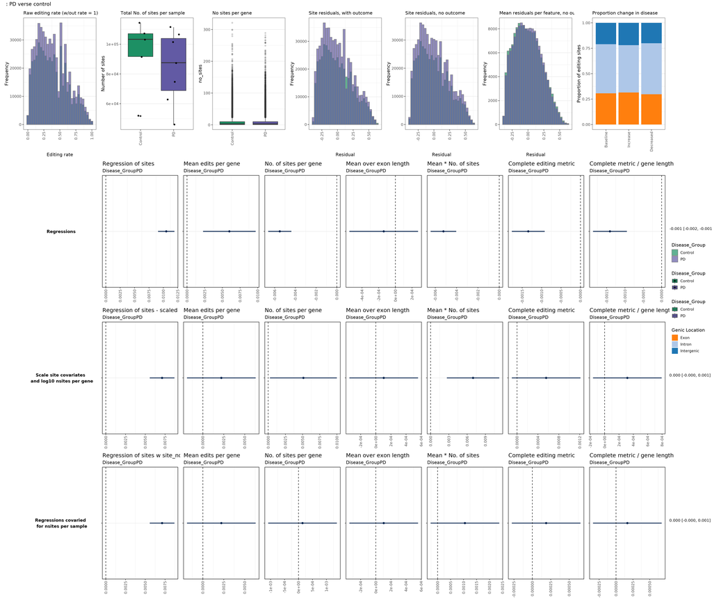

## 2.2 Control vs. DLB

[1] “Exploring : Control vs. DLB” [1] “Control group; 5 samples” [1] “DLB group; 6 samples” [1] “Grouping gene summary by:” [1] “Sample” “gene_id” “Disease_Group” “RIN”  
[5] “Sex”  
[1] “0 out of 7369 genes do not have a gene length.” [1] “Grouping gene summary by:” [1] “Sample” “gene_id” “Disease_Group” “RIN”  
[5] “Sex”  
[1] “0 out of 7369 genes do not have a gene length.” [1] “Grouping gene summary by:” [1] “Sample” “gene_id” “Disease_Group” “RIN”  
[5] “Sex”  
[1] “0 out of 7369 genes do not have a gene length.”

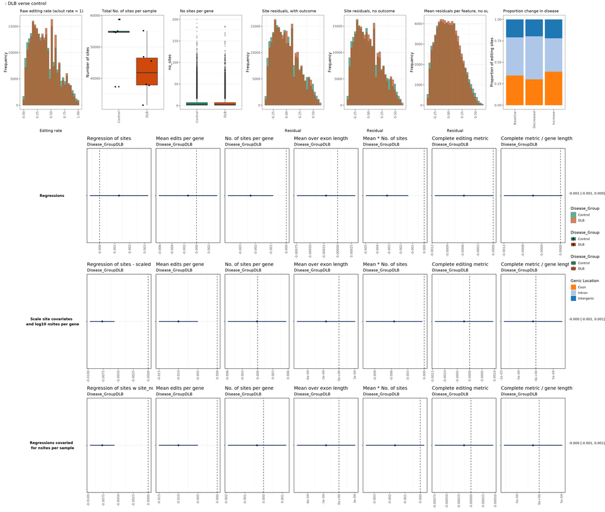

## 2.3 Control vs. PDD

[1] “Exploring : Control vs. PDD” [1] “Control group; 5 samples” [1] “PDD group; 6 samples” [1] “Grouping gene summary by:” [1] “Sample” “gene_id” “Disease_Group” “RIN”  
[5] “Sex”  
[1] “0 out of 9368 genes do not have a gene length.” [1] “Grouping gene summary by:” [1] “Sample” “gene_id” “Disease_Group” “RIN”  
[5] “Sex”  
[1] “0 out of 9368 genes do not have a gene length.” [1] “Grouping gene summary by:” [1] “Sample” “gene_id” “Disease_Group” “RIN”  
[5] “Sex”  
[1] “0 out of 9368 genes do not have a gene length.”

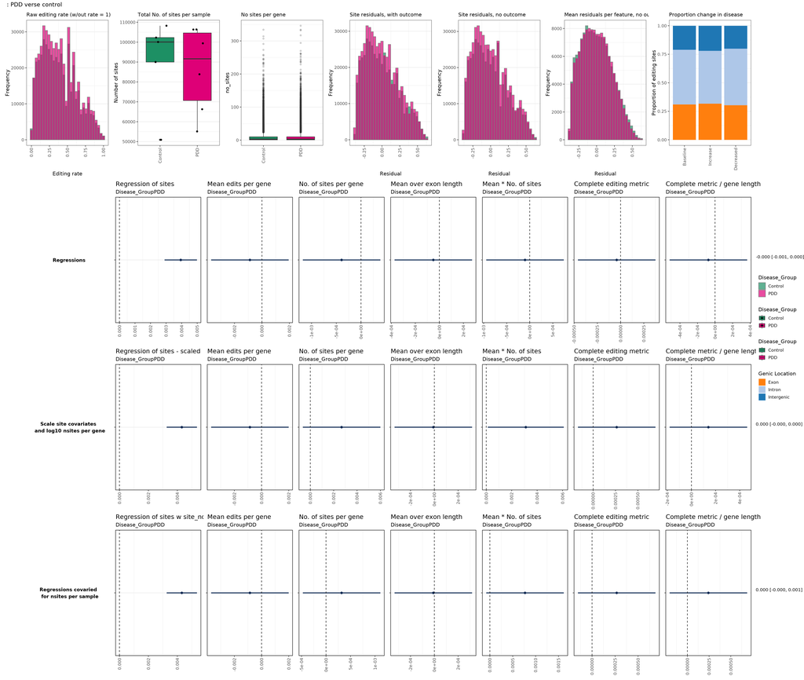

```r
# quantile_cuttoff <- 0.9
#
# lm_results_sites$sites_subset_residuals_with_outcome %>%
#   ggplot(aes(x = `.resid`)) +
#   geom_histogram(bins = 50) +
#   geom_vline(aes(xintercept = quantile(`.resid`, quantile_cuttoff)))
```

```r
#
# outliers <- lm_results_sites$sites_subset_residuals_with_outcome %>%
#   dplyr::filter(.resid > quantile(lm_results_sites$sites_subset_residuals_with_outcome$.resid, quantile_cuttoff))
#
# outliers %>%
#   ggplot(aes(x = Edits)) +
#   geom_boxplot()
#
# outliers %>%
#   ggplot(aes(x = Disease_Group)) +
#   geom_bar(stat = "count")
```